# General exploration of gene content in Casei group genomes

Stijn Wittouck

15th of June 2017

```r
library(tidyverse)
library(stringr)
library(vegan)
source(file = "function_make_pcoaTable.R")
```

# 1 Loading the data

We start by reading in the necessary tables.

```r
load(file = "intermediate/V_genome_orthogroup.Robject")
load(file = "intermediate/T_genome.Robject")
load(file = "intermediate/T_orthogroup.Robject")
load(file = "intermediate/T_eggnogFam_functCat.Robject")
T_functCat <- read_tsv(file = "input/functCat_descriptions.tsv")
```

# 2 Summary statistics of casei group and clades

We want the following information for each clade: number of genomes, number of core orthogroups, number of accessory orthogroups, average number of orthogroups per genome, average number of genes per genome.

```r
calculateCladeStatistics <- function(V_genome_orthogroup) {

  part1 <- V_genome_orthogroup %>%
    select(genome) %>%
    distinct() %>%
    summarise(nGenomes = n())
  nGenomesTot <- part1[[1]][1]

  part2 <- V_genome_orthogroup %>%
    group_by(orthogroup) %>%
    summarise(ngenomes = sum(ngenes != 0)) %>%
    summarise(nCoreOrthogroups = sum(ngenomes >= (0.96 * nGenomesTot)),
              nAccOrthogroups = sum(ngenomes < (0.96 * nGenomesTot)))

  part3 <- V_genome_orthogroup %>%
    group_by(genome) %>%
    summarise(nOrthogroups = sum(ngenes != 0), nGenes = sum(ngenes)) %>%
    summarise(avnOrthogroups = mean(nOrthogroups), avnGenes = mean(nGenes),
              sdnOrthogroups = sd(nOrthogroups), sdnGenes = sd(nGenes))

  return(cbind(part1, part2, part3))

}

left_join(V_genome_orthogroup, T_genome) %>%
  list(
    .,
    filter(., clade == "cladeA"),
    filter(., clade == "cladeB"),
    filter(., clade == "cladeC")
  ) %>%
  lapply(FUN = calculateCladeStatistics) %>%
  bind_rows() %>%
  mutate(clade = c("casei group", "clade A", "clade B", "clade C")) %>%
  column_to_rownames(var = "clade")
```

```
##             nGenomes nCoreOrthogroups nAccOrthogroups avnOrthogroups
## casei group      184             1814            4102       2654.457
## clade A           70             1924            2867       2696.543
## clade B           10             1924            1577       2615.500
## clade C          104             2133            2364       2629.875
##             avnGenes sdnOrthogroups sdnGenes
## casei group 2834.603       91.66563 146.4423
## clade A     2904.129      106.45455 149.9475
## clade B     2862.700       95.74648 111.7179
## clade C     2785.106       67.63791 126.9392
```

# 3 Visualization of gene content comparisons

## 3.1 PCoA for all orthogroups

Let’s make a PCoA plot of the overall pairwise distances between genomes in terms of gene content (Bray-Curtis). The colors match the ones used in the tree figures.

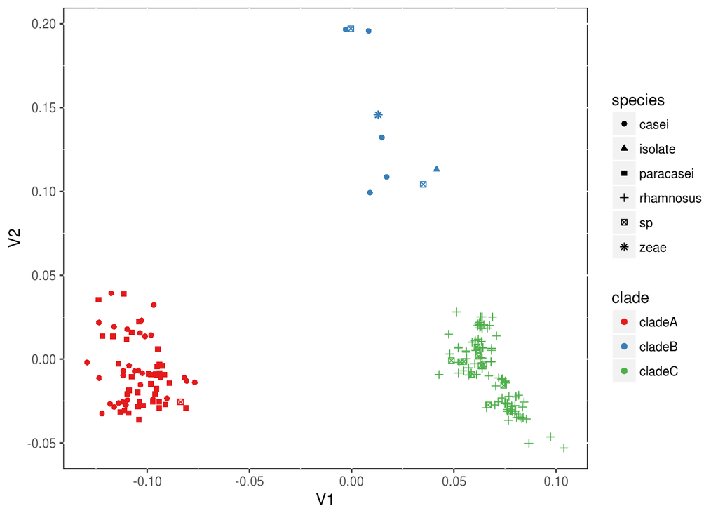

```r
# make table with pcoa coordinates for all genomes
# also add genome info (clade, species)
T_pcoa1 <- make_pcoaTable(V_genome_orthogroup) %>%
  left_join(T_genome)

# same clade colors as in trees
cladeColors <- c("cladeA" = "#e41a1c", "cladeB" = "#377eb8", "cladeC" = "#4daf4a")

# plot and save
ggplot(T_pcoa1, aes(x = V1, y = V2, col = clade, shape = species)) +
  geom_point() +
  scale_color_manual(values = cladeColors) +
  theme(panel.background = element_rect(fill = 'white', colour = 'black'))
```

```r
ggsave(filename = "results/pcoa_overall.png", height = 20, width = 30, units = "cm")
```